# Group spcyt transcripts by number of CAGE TSS

Dan Lu

2/18/19

## **spcyt g1: gene off to on, contains only Hcc**

1. hs48 vs bam: log2FoldChange > 3 OR hs72 vs bam: log2FoldChange > 4
2. off in bam RNA < 8
3. contains only Hcc
4. if >1 Hcc, write out the one if it is most expressed and most upstream

## **spcyt g2: gene on to on, contains Bcc and Hcc**

1. gene contains Bcc and Hcc (gene_cc_type is “both”)
2. gene on in bam RNA > 5, on in HS72 RNA > 5
3. for each gene, only keep 1 Bcc: if > 1 Bcc, use the one if it is most expressed and most upstream
4. only keep 1 Hcc: if > 1 Hcc, use the one if it is most expressed and most upstream  
   **g2up: Hcc is upstream of Bcc**  
   **g2down: Hcc is downstrame of Bcc**

```r
suppressMessages(library(tidyverse))
suppressMessages(library(magrittr))
library(gridExtra)
options(tibble.width = Inf)
options(scipen=999)

source("~/Dropbox/coding/R/my_package/genomicsDL/R/get_TSS.r")
source("~/Dropbox/coding/R/my_package/genomicsDL/R/get_TES.r")
```

```r
log2FoldChange_cut_b4=3
log2FoldChange_cut_b7=4
#log2FoldChange_cut_aly=-1
#log2FoldChange_cut_cage=4
qval_cut=0.001
on_cut_RNA=5
g1_cut_bam_RNA=8
```

## load rlog for both RNA and CAGE, contains gene ID, consensus cluster ID and gene_cc_type

Note each gene has multiple CAGE intersection rows

```r
rlog_all <- read.delim("BDGP6_coding_up500_5utr_CDS_RNA_CAGE_rlog.txt", stringsAsFactors=FALSE)

table(rlog_all$cc_type) # for cluster
```

```
##
##   Bcc   Hcc
## 10199  3797
```

```r
table(rlog_all$gene_cc_type) # for gene
```

```
##
##  Bcc_gene both_gene  Hcc_gene
##      8275      3222      2255
```

## load cc to domTSS conversion table

```r
ccB <- read.delim("consensusCluster_B_domTSS1bp_width_table.txt", stringsAsFactors=FALSE)
names(ccB)
```

```
##  [1] "V1"                  "V2"                  "V3"
##  [4] "cluster_id"          "cc_tpm"              "V6"
##  [7] "V7"                  "V8"                  "domTSS"
## [10] "V10"                 "avg_tpm"             "V12"
## [13] "interquantile_width"
```

```r
ccH <- read.delim("consensusCluster_H_domTSS1bp_width_table.txt", stringsAsFactors=FALSE)
names(ccH)
```

```
##  [1] "V1"                  "V2"                  "V3"
##  [4] "cluster_id"          "cc_tpm"              "V6"
##  [7] "V7"                  "V8"                  "domTSS"
## [10] "V10"                 "avg_tpm"             "V12"
## [13] "interquantile_width"
```

# **g1: off-on, only Hcc**

### (1) hs48 vs bam: log2FoldChange > 3 OR hs72 vs bam: log2FoldChange > 4

```r
b4 <- read.delim("DE_HS48vsBam_RNA_results_all.txt", stringsAsFactors=FALSE)

spcyt_b4 = filter(b4, log2FoldChange > log2FoldChange_cut_b4 & padj < qval_cut)

b7 <- read.delim("DE_HS72vsBam_RNA_results_all.txt", stringsAsFactors=FALSE)

spcyt_b7 = filter(b7, log2FoldChange > log2FoldChange_cut_b7 & padj < qval_cut)

spcyt_b47_id = full_join(select(spcyt_b4,X), select(spcyt_b7,X))

g1 = semi_join(rlog_all, spcyt_b47_id,by="X")
nrow(g1)
```

```
## [1] 2360
```

### (2) off in bam RNA < cut

### (3) contains only Hcc

```r
# only Hcc gene
g1%<>% filter(gene_cc_type=="Hcc_gene") %>% filter(bam_RNA < g1_cut_bam_RNA)
nrow(g1)
```

```
## [1] 2102
```

### (3) if >1 Hcc, write out the one if it is most expressed and most upstream

```r
# add in domTSS and cluster coordinate from HS72 CAGE
g1 %<>% inner_join(ccH, by=c("V10"="cluster_id"))
nrow(g1)
```

```
## [1] 2102
```

```r
# keep the most upstream = most expressed Hcc
########## find the more upstream cluster
# on + strand, sort by genomic coordinate, and remove the 2nd duplicate for each gene
g1_fw=filter(g1, V12=="+") %>% arrange(V7, domTSS)
g1_fw_unq=g1_fw[!duplicated(g1_fw["X"]),]

# on - strand, sort by reverse genomic coordiante, and remove the 2nd duplicate for each gene
g1_rv=filter(g1, V12=="-") %>% arrange(V7, -domTSS)
g1_rv_unq=g1_rv[!duplicated(g1_rv["X"]),]

g1_upstream=bind_rows(g1_fw_unq, g1_rv_unq)
nrow(g1_upstream)
```

```
## [1] 1713
```

```r
######### find the more expressed cluster
g1 %<>% arrange(-HS72_CAGE)
g1_higher=g1[!duplicated(g1["X"]),]
nrow(g1_higher)
```

```
## [1] 1713
```

```r
g1_unq = inner_join(g1_upstream, g1_higher)
nrow(g1_unq)
```

```
## [1] 1644
```

# **spcyt g2: gene on to on, contains Bcc and Hcc**

1. gene contains Bcc and Hcc (gene_cc_type is “both”)
2. gene on in bam RNA > cut, on in HS72 RNA > cut
3. for each gene, only keep 1 Bcc: if > 1 Bcc, use the one if it is most expressed and most upstream
4. only keep 1 Hcc: if > 1 Hcc, use the one if it is most expressed and most upstream

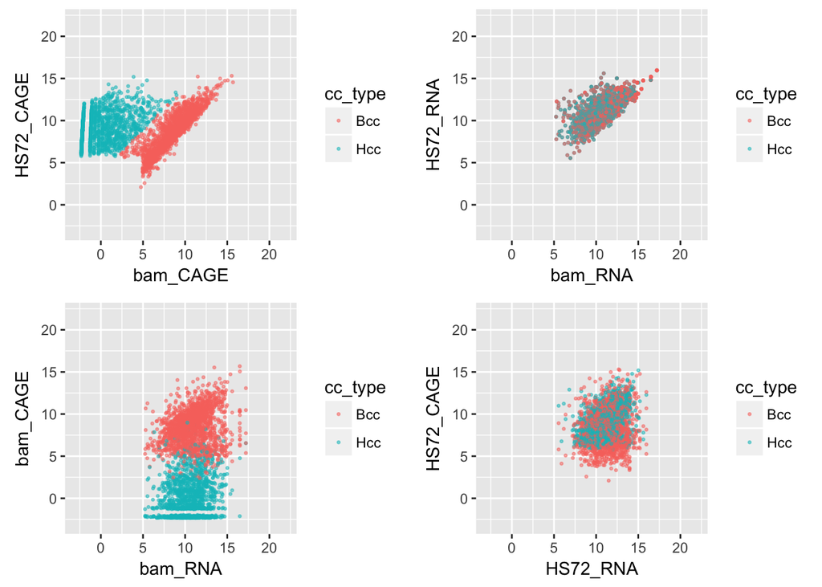

```r
g2 = filter(rlog_all, gene_cc_type=="both_gene") %>% filter(bam_RNA > on_cut_RNA & HS72_RNA > on_cut_RNA)

# take a look at RNA CAGE
p1=ggplot(g2, aes(bam_CAGE, HS72_CAGE)) + geom_point(size=0.5, alpha=0.5, aes(color=cc_type)) + xlim(-3,22) + ylim(-3,22) + coord_fixed(ratio=1)

p2=ggplot(g2, aes(bam_RNA, bam_CAGE)) + geom_point(size=0.5, alpha=0.5, aes(color=cc_type)) + xlim(-3,22) + ylim(-3,22) + coord_fixed(ratio=1)

p3=ggplot(g2, aes(HS72_RNA, HS72_CAGE)) + geom_point(size=0.5, alpha=0.5, aes(color=cc_type)) + xlim(-3,22) + ylim(-3,22) + coord_fixed(ratio=1)

p4=ggplot(g2, aes(bam_RNA, HS72_RNA)) + geom_point(size=0.5, alpha=0.5, aes(color=cc_type)) + xlim(-3,22) + ylim(-3,22) + coord_fixed(ratio=1)

grid.arrange(p1, p4, p2, p3, ncol=2)
```

## for each gene, only keep 1 Bcc: if > 1 Bcc, use the one if it is both more upstream AND more expressed

```r
g2_B=filter(g2, cc_type=="Bcc")
nrow(g2_B)
```

```
## [1] 1770
```

```r
g2_B %<>% inner_join(ccB, by=c("V10"="cluster_id"))
nrow(g2_B) # some cc are lost due to not having a domTSS1bp
```

```
## [1] 1754
```

```r
########## find the more upstream cluster
# on + strand, sort by genomic coordinate, and remove the 2nd duplicate for each gene
g2_B_fw=filter(g2_B, V12=="+") %>% arrange(V7, domTSS)
g2_B_fw_unq=g2_B_fw[!duplicated(g2_B_fw["X"]),]

# on - strand, sort by reverse genomic coordiante, and remove the 2nd duplicate for each gene
g2_B_rv=filter(g2_B, V12=="-") %>% arrange(V7, -domTSS)
g2_B_rv_unq=g2_B_rv[!duplicated(g2_B_rv["X"]),]

g2_B_upstream=bind_rows(g2_B_fw_unq, g2_B_rv_unq)
nrow(g2_B_upstream)
```

```
## [1] 1208
```

```r
######### find the more expressed cluster
g2_B %<>% arrange(-bam_CAGE)
g2_B_higher=g2_B[!duplicated(g2_B["X"]),]
nrow(g2_B_higher)
```

```
## [1] 1208
```

```r
g2_B_unq = inner_join(g2_B_upstream, g2_B_higher) %>% select(X, V10, cc_type, V7:interquantile_width)
nrow(g2_B_unq)
```

```
## [1] 1115
```

## for each gene, only keep 1 Hcc: if > 1 Hcc, use the one if it is both more upstream AND more expressed

```r
g2_H=filter(g2, cc_type=="Hcc")
nrow(g2_H)
```

```
## [1] 1407
```

```r
g2_H %<>% inner_join(ccH, by=c("V10"="cluster_id"))
nrow(g2_H)
```

```
## [1] 1407
```

```r
nrow(unique(select(g2_H,X)))
```

```
## [1] 1210
```

```r
########## find the more upstream cluster
# on + strand, sort by genomic coordinate, and remove the 2nd duplicate for each gene
g2_H_fw=filter(g2_H, V12=="+") %>% arrange(V7, domTSS)
g2_H_fw_unq=g2_H_fw[!duplicated(g2_H_fw["X"]),]

# on - strand, sort by reverse genomic coordiante, and remove the 2nd duplicate for each gene
g2_H_rv=filter(g2_H, V12=="-") %>% arrange(V7, -domTSS)
g2_H_rv_unq=g2_H_rv[!duplicated(g2_H_rv["X"]),]

g2_H_upstream=bind_rows(g2_H_fw_unq, g2_H_rv_unq)
nrow(g2_H_upstream)
```

```
## [1] 1210
```

```r
######### find the more expressed cluster
# sort by decreasing CAGE level, and remove the 2nd duplicate for each gene
g2_H %<>% arrange(-HS72_CAGE)
g2_H_higher=g2_H[!duplicated(g2_H["X"]),]
nrow(g2_H_higher)
```

```
## [1] 1210
```

```r
g2_H_unq = inner_join(g2_H_upstream, g2_H_higher) %>% select(X, V10, cc_type, V7:interquantile_width)
nrow(g2_H_unq)
```

```
## [1] 1126
```

## only keep genes that have both Bcc and Hcc

```r
g2_B_H_unq=inner_join(g2_B_unq, g2_H_unq, by="X")
nrow(g2_B_H_unq)
```

```
## [1] 1038
```

```r
names(g2_B_H_unq)
```

```
##  [1] "X"                     "V10.x"
##  [3] "cc_type.x"             "V7.x"
##  [5] "V8.x"                  "domTSS.x"
##  [7] "V10.y.x"               "avg_tpm.x"
##  [9] "V12.x"                 "interquantile_width.x"
## [11] "V10.y.y"               "cc_type.y"
## [13] "V7.y"                  "V8.y"
## [15] "domTSS.y"              "V10.y.y.y"
## [17] "avg_tpm.y"             "V12.y"
## [19] "interquantile_width.y"
```

```r
# make sure there is only 1 entry for each gene which should be the case given that for each gene only kept 1 Bcc and 1 Hcc
nrow(unique(select(g2_B_H_unq,X)))
```

```
## [1] 1038
```

```r
# check Bcc and Hcc are on the same strand
nrow(filter(g2_B_H_unq,V7.x==V7.y))
```

```
## [1] 1038
```

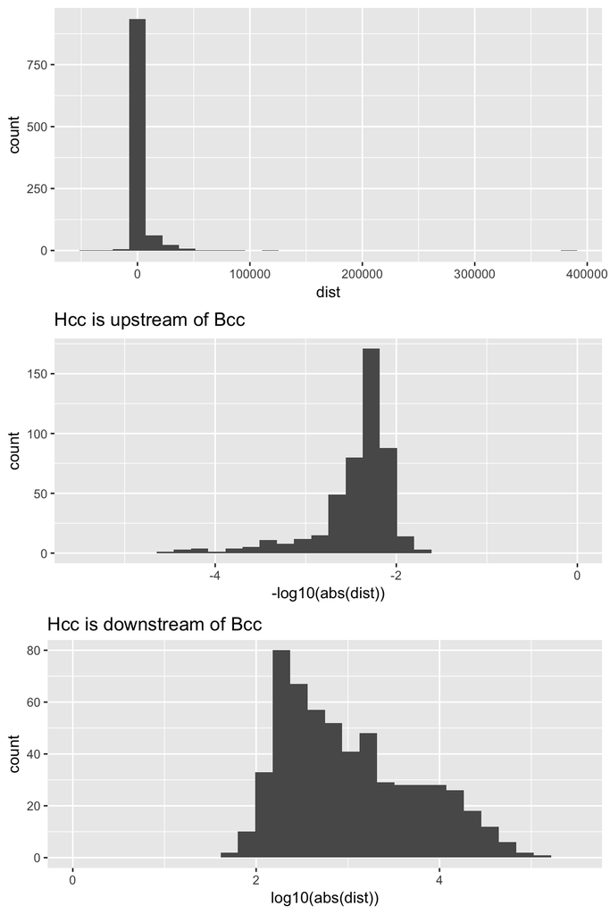

```r
# add distance from Hcc to Bcc
g2_B_H_unq_fw = filter(g2_B_H_unq, V12.x=="+") %>% mutate(dist=domTSS.y-domTSS.x)
g2_B_H_unq_rv = filter(g2_B_H_unq, V12.x=="-") %>% mutate(dist=domTSS.x-domTSS.y)
g2_B_H_unq = bind_rows(g2_B_H_unq_fw, g2_B_H_unq_rv)


u1=ggplot(g2_B_H_unq, aes(dist))+geom_histogram()
u2=filter(g2_B_H_unq, dist < 0) %>% ggplot(aes(-log10(abs(dist))))+geom_histogram()+ggtitle("Hcc is upstream of Bcc")+xlim(-5.5,0)
u3=filter(g2_B_H_unq, dist > 0) %>% ggplot(aes(log10(abs(dist))))+geom_histogram()+ggtitle("Hcc is downstream of Bcc")+xlim(0,5.5)
grid.arrange(u1,u2,u3)
```

# remover overlap and write output

```r
overlap=inner_join(g1_unq, g2_B_H_unq, by=c("V10"="V10.y.y")) %>% select(V10)
print(overlap)
```

```
##            V10
## 1 cluster10620
## 2 cluster14016
```

```r
g1_unq %<>% anti_join(overlap, by=c("V10"="V10"))
g2_B_H_unq %<>% anti_join(overlap, by=c("V10.y.y"="V10"))
```

## write output for g1, sort by interquantile width

```r
write.table(g1_unq, "spcyt_g1_Hcc_all_cc.txt", sep="\t", quote=F, col.names = T, row.names = F)

g1_bed = select(g1_unq, V7:V10.y, interquantile_width, V12) %>% arrange(interquantile_width) %>% unique()
nrow(g1_bed)
```

```
## [1] 1640
```

```r
write.table(g1_bed, "spcyt_g1_Hcc_unq_domTSS1bp_srt_width_cc.bed", sep="\t", quote=F, col.names = F, row.names = F)

g1_ID = select(g1_unq, X, V10, V10.y) %>% arrange(X)
write.table(g1_ID, "spcyt_g1_Hcc_ID_cc.txt", sep="\t", quote=F, col.names = F, row.names = F)
```

## write output for g2:Bcc, Hcc_up, Hcc_down. All sort by interquantile width

```r
write.table(g2_B_H_unq, "spcyt_g2_all_cc.txt", sep="\t", quote=F, col.names = T, row.names = F)

# write bed files
g2_Bccup_bed = filter(g2_B_H_unq, dist < 0) %>% select( V7.x:V10.y.x, interquantile_width.x, V12.x) %>% arrange(interquantile_width.x) %>% unique()
nrow(g2_Bccup_bed)
```

```
## [1] 466
```

```r
g2_Hccup_bed = filter(g2_B_H_unq, dist < 0) %>%  select(V7.y:V10.y.y.y, interquantile_width.y, V12.y) %>% arrange(interquantile_width.y) %>% unique()
nrow(g2_Hccup_bed)
```

```
## [1] 466
```

```r
g2_Bccdown_bed = filter(g2_B_H_unq, dist > 0) %>% select( V7.x:V10.y.x, interquantile_width.x, V12.x) %>% arrange(interquantile_width.x) %>% unique()
nrow(g2_Bccdown_bed)
```

```
## [1] 565
```

```r
g2_Hccdown_bed = filter(g2_B_H_unq, dist > 0) %>%  select(V7.y:V10.y.y.y, interquantile_width.y, V12.y) %>% arrange(interquantile_width.y) %>% unique()
nrow(g2_Hccdown_bed)
```

```
## [1] 566
```

```r
write.table(g2_Bccup_bed, "spcyt_g2_Bcc_UP_unq_domTSS1bp_srt_width_cc.bed", sep="\t", quote=F, col.names = F, row.names = F)

write.table(g2_Bccdown_bed, "spcyt_g2_Bcc_DOWN_unq_domTSS1bp_srt_width_cc.bed", sep="\t", quote=F, col.names = F, row.names = F)

write.table(g2_Hccup_bed, "spcyt_g2_Hcc_UP_unq_domTSS1bp_srt_width_cc.bed", sep="\t", quote=F, col.names = F, row.names = F)

write.table(g2_Hccdown_bed, "spcyt_g2_Hcc_DOWN_unq_domTSS1bp_srt_width_cc.bed", sep="\t", quote=F, col.names = F, row.names = F)


# write ID files
g2_ID = select(g2_B_H_unq, X, cc_type.x, V10.x, V10.y.x, cc_type.y, V10.y.y, V10.y.y.y, dist) %>% unique() %>% arrange(X)
nrow(g2_ID)
```

```
## [1] 1036
```

```r
## also create ID that will match the format of g1 and spgn
g2_Bccup_ID = filter(g2_B_H_unq, dist < 0) %>% select(X, V10.x, V10.y.x, cc_type.x) %>% unique() %>% arrange(X)
nrow(g2_Bccup_ID)
```

```
## [1] 467
```

```r
g2_Hccup_ID = filter(g2_B_H_unq, dist < 0) %>% select(X, V10.y.y, V10.y.y.y,  cc_type.y) %>% unique() %>% arrange(X)

g2_Bccdown_ID = filter(g2_B_H_unq, dist > 0) %>% select(X, V10.x, V10.y.x, cc_type.x) %>% unique() %>% arrange(X)
nrow(g2_Bccdown_ID)
```

```
## [1] 569
```

```r
g2_Hccdown_ID = filter(g2_B_H_unq, dist > 0) %>% select(X, V10.y.y, V10.y.y.y,  cc_type.y) %>% unique() %>% arrange(X)


write.table(g2_ID, "spcyt_g2_ID_cc.txt", sep="\t", quote=F, col.names = F, row.names = F)

write.table(g2_Bccup_ID, "spcyt_g2_Bcc_UP_ID_cc.txt", sep="\t", quote=F, col.names = F, row.names = F)

write.table(g2_Bccdown_ID, "spcyt_g2_Bcc_DOWN_ID_cc.txt", sep="\t", quote=F, col.names = F, row.names = F)

write.table(g2_Hccup_ID, "spcyt_g2_Hcc_UP_ID_cc.txt", sep="\t", quote=F, col.names = F, row.names = F)

write.table(g2_Hccdown_ID, "spcyt_g2_Hcc_DOWN_ID_cc.txt", sep="\t", quote=F, col.names = F, row.names = F)
```